# Finance

Luciano Santos

28/04/2021

# Analise descritiva

Neste grafico podemos observar o número de transações por grupo de estabelecimento

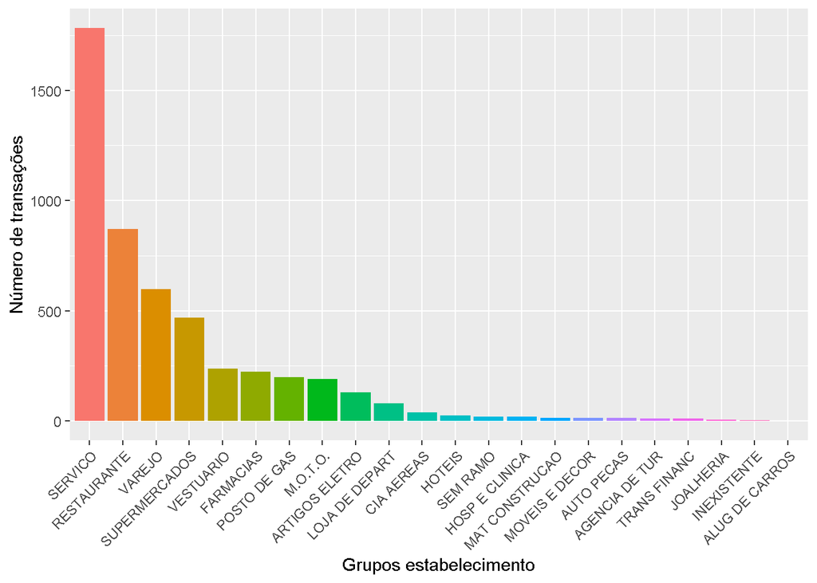

```r
library(ggplot2)
ggplot(data = ramo,aes(x = Var1,y = Freq,fill = Var1))+
  geom_col()+
  theme(axis.text.x = element_text(angle = 45, vjust = 1, hjust=1),legend.position = "none")+
  scale_fill_discrete(name = "Grupos estabelecimento")+
  labs(x = "Grupos estabelecimento",y = "Número de transações")
```

No qual o grupo de Serviço aparece como o principal no segmento de estabelecimentos, com o aluguel de carros se encontrando no que tem menos transações.

Conseguimos identificar que o banco de dados se trata de transações de 28 usuarios ao longo de Abril de 2019 até Maio de 2020.

```r
numero.transacoes.id <- finance%>%group_by(id)%>%
                      summarise(contagem = n())
print(numero.transacoes.id$id)
```

```
##  [1] "1,00E+12"    "1,79E+11"    "1883101787"  "2,21E+11"    "2,46E+11"
##  [6] "3,09E+11"    "3,31E+11"    "3,48E+11"    "4,23E+11"    "4,53E+11"
## [11] "5,02E+11"    "5,38E+11"    "5,43E+11"    "5,81E+11"    "5,87E+11"
## [16] "5,91E+11"    "6,06E+11"    "6,51E+11"    "64831300521" "7,04E+11"
## [21] "7,91E+11"    "8,14E+11"    "8,61E+11"    "8,99E+11"    "9,19E+11"
## [26] "9,54E+11"    "94873707154" "9813602284"
```

Optamos por deixar a variavel de uma forma mais agradavel

```r
finance <- finance %>% mutate(id = factor(id,labels = c(1:length(unique(finance$id)))))
numero.transacoes.id <- finance%>%group_by(id)%>%
                      summarise(contagem = n())
print(numero.transacoes.id$id)
```

```
##  [1] 1  2  3  4  5  6  7  8  9  10 11 12 13 14 15 16 17 18 19 20 21 22 23 24 25
## [26] 26 27 28
## 28 Levels: 1 2 3 4 5 6 7 8 9 10 11 12 13 14 15 16 17 18 19 20 21 22 23 ... 28
```

A média de idade dos cliente é de 35.71 anos, tendo como idade minima 20 anos e máxima de 53 anos.

```r
idade.id <- finance%>%group_by(id)%>%
                      summarise(idade = max(idade))
cat("idade minima: ",min(idade.id$idade),"\n idade media: ",mean(idade.id$idade),"\n idade maxima: ",max(idade.id$idade))
```

```
## idade minima:  20
##  idade media:  35.71429
##  idade maxima:  53
```

E se formos considerar a volume de transações de acordo com a idade, podemos observar na media ponderada que segue o mesmo caminho da media arimetrica simples, tendo uma média de 34.23 anos

```r
sum(idade.id$idade*numero.transacoes.id$contagem)/sum(numero.transacoes.id$contagem)
```

```
## [1] 34.23209
```

```r
numero.transacoes.id %>% arrange(desc(contagem))
```

```
## # A tibble: 28 x 2
##    id    contagem
##    <fct>    <int>
##  1 11         701
##  2 18         510
##  3 7          458
##  4 4          268
##  5 27         259
##  6 12         257
##  7 17         250
##  8 16         209
##  9 22         193
## 10 26         192
## # ... with 18 more rows
```

Obtemos então o valor consumido por cada cliente durante o periodo estudado:

```r
valor.id <- finance%>%group_by(id)%>%
  summarise(valor_total = sum(valor,na.rm = T))
valor.id %>% arrange(desc(valor_total))
```

```
## # A tibble: 28 x 2
##    id    valor_total
##    <fct>       <dbl>
##  1 17        151744.
##  2 1          46793.
##  3 7          39501.
##  4 4          37023.
##  5 11         31114.
##  6 23         25350.
##  7 12         21523.
##  8 26         19785.
##  9 22         18700.
## 10 21         16562.
## # ... with 18 more rows
```

Podemos observar que o cliente 17, foi que teve o maior valor total nas transações analisadas

Utilizando os dados de formal geral, não observamos uma relação média ou forte entre a idade dos clientes com o valor total gasto no periodo dos dados estudados, algo que podemos reforçar no gráfico abaixo.

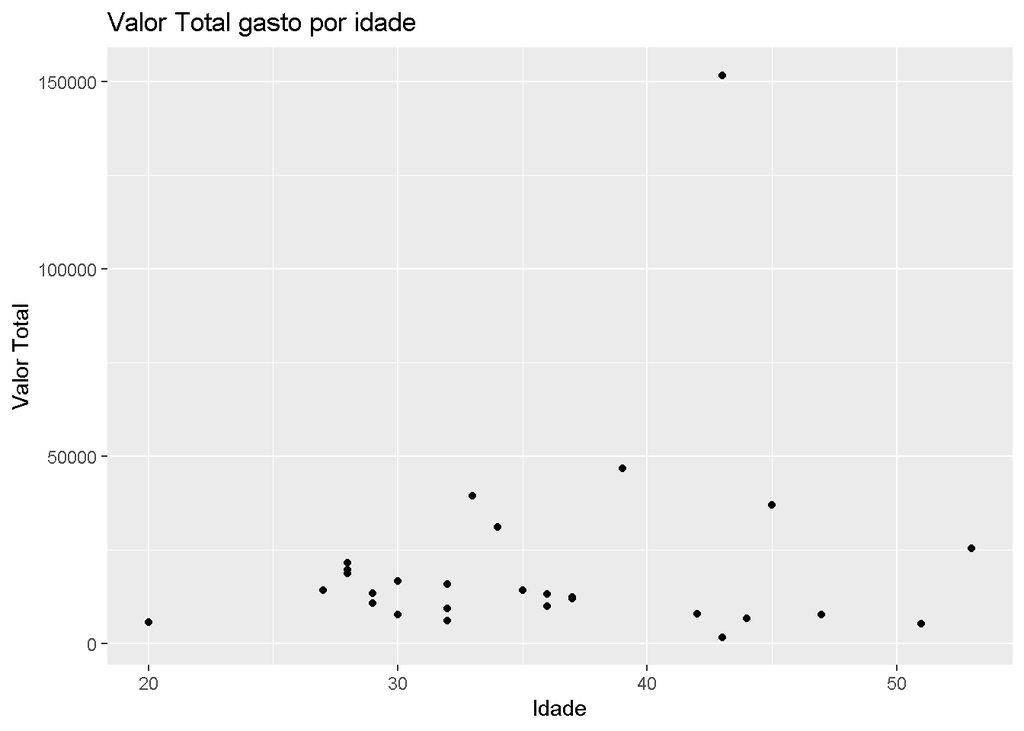

```r
idade.valor <- data.frame(idade = idade.id$idade,
                          valor_total = valor.id$valor_total)
ggplot(data = idade.valor,aes(x = idade,y = valor_total))+
  geom_point()+
  labs(x = "Idade",y = "Valor Total",title = "Valor Total gasto por idade")
```

Essa baixa relação pode ser confirmada tambem através no coeficiente de Pearson, no qual apresenta o seguinte valor:

```r
cor(idade.valor$idade,idade.valor$valor_total)
```

```
## [1] 0.1848253
```

Nos informando existir uma baixa relação positiva ou relação nehuma entre as variaveis idade e valor total gasto nas transações